# Desafío 1: Determinar probabilidad de churn

El objetivo del desafío es desarrollar un modelo que pueda predecir si un cliente dejará la compañía. Es muy importante justificar la elección del sistema (o modelo), el trabajo previo de la data (EDA) y la documentación de lo que se hizo (no es necesario un informe, pero si comentar porqué se tomaron las decisiones que se tomaron; por ej eliminar una variable o eliminar registros missing, etc).

La variable "Churn" tiene dos niveles, y como el objetivo es predecir si un cliente dejara la compañía, por lo tanto, es un problema de clasificación, en este caso podríamos utilizar una regresión logística binomial, cuyas variables predictoras serian las otras columnas del conjunto de datos, y la variable dependiente "Churn".

```python
#cargamos los datos
import pandas as pd
import numpy as np
import matplotlib.pyplot as plt
import pandas as pd
df = pd.read_csv(r"C:\Users\Cristopher\Desktop\Desafio_lipigas\Archivo data - 2022.csv", sep=",")
df.head()
```

|  | customerID | gender | SeniorCitizen | Partner | Dependents | tenure | PhoneService | MultipleLines | InternetService | OnlineSecurity | ... | DeviceProtection | TechSupport | StreamingTV | StreamingMovies | Contract | PaperlessBilling | PaymentMethod | MonthlyCharges | TotalCharges | Churn |
| --- | --- | --- | --- | --- | --- | --- | --- | --- | --- | --- | --- | --- | --- | --- | --- | --- | --- | --- | --- | --- | --- |
| 0 | 7590-VHVEG | Female | 0 | Yes | No | 30 | No | No phone service | DSL | No | ... | No | No | No | No | Month-to-month | Yes | Electronic check | 29.85 | 29.85 | No |
| 1 | 5575-GNVDE | Male | 0 | No | No | 1020 | Yes | No | DSL | Yes | ... | Yes | No | No | No | One year | No | Mailed check | 56.95 | 1889.5 | No |
| 2 | 3668-QPYBK | Male | 0 | No | No | 60 | Yes | No | DSL | Yes | ... | No | No | No | No | Month-to-month | Yes | Mailed check | 53.85 | 108.15 | Yes |
| 3 | 7795-CFOCW | Male | 0 | No | No | 1350 | No | No phone service | DSL | Yes | ... | Yes | Yes | No | No | One year | No | Bank transfer (automatic) | 42.30 | 1840.75 | No |
| 4 | 9237-HQITU | Female | 0 | No | No | 60 | Yes | No | Fiber optic | No | ... | No | No | No | No | Month-to-month | Yes | Electronic check | 70.70 | 151.65 | Yes |

5 rows × 21 columns

Tenemos 7043 filas datos de clientes y 21 variables o columnas.

```python
df.shape
```

```
(7043, 21)
```

Se calcula el porcentaje de hombres y mujeres que abandonaron, y no abandonan.

```python
tabla_contingencia = pd.crosstab(df["gender"], df["Churn"])
tabla_contingencia
```

| Churn gender | No | Yes |
| --- | --- | --- |
| Female | 2549 | 939 |
| Male | 2625 | 930 |

```python
tabla_contingencia.astype("float").div(tabla_contingencia.sum(axis=1), axis=0)
```

| Churn gender | No | Yes |
| --- | --- | --- |
| Female | 0.730791 | 0.269209 |
| Male | 0.738397 | 0.261603 |

No parece existir una gran diferencia entre los hombres y las mujeres respecto que abandonan.

```python
tabla_contingencia.astype("float").div(tabla_contingencia.sum(axis=1), axis=0)
```

| Churn gender | No | Yes |
| --- | --- | --- |
| Female | 0.730791 | 0.269209 |
| Male | 0.738397 | 0.261603 |

Se pueden realizar gráficos para explorar si existe alguna diferencia de abandono entre quienes utilizan DSL, Fiber Optic y "No"

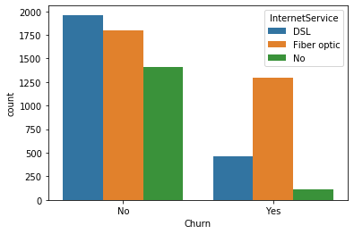

```python
sns.countplot(x='Churn',data=df, hue='InternetService')
```

Entre los que abandonan los que utilizan "Fiber Optic" pareciera que tienen una mayor rotación.

Si quisiéramos observar si el tipo de pago tiene alguna influencia en "Churn"

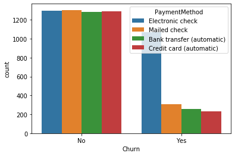

```python
sns.countplot(x='Churn',data=df, hue='PaymentMethod')
```

Los que tienen como método de pago "electronic check" tienden a estar sobrerepresentados entre los que abandonan.

Ahora comprobamos si el tener facturación electrónica está vinculado al abandono de la compañía

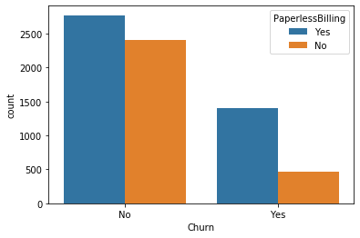

```python
sns.countplot(x='Churn',data=df, hue='PaperlessBilling')
```

Entre los que abandonan, parecen tener una tendencia hacía poseer factura electrónica.

Si quisiéramos saber la relación entre la antigüedad del cliente en días y si el cliente ha dejado la compañía:

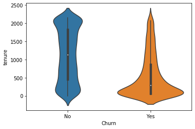

```python
import seaborn as sns

sns.violinplot(x="Churn", y="tenure", data=df);
```

Se observa que los de menor antigüedad tienden a dejar la compañía.

Si quisiéramos saber cuantos clientes abandonaron, primero procedemos a transformar las variables en variables dummies.

```python
df["Churn"] = (df.Churn=='Yes').astype(int)
df.head()
```

|  | customerID | gender | SeniorCitizen | Partner | Dependents | tenure | PhoneService | MultipleLines | InternetService | OnlineSecurity | ... | DeviceProtection | TechSupport | StreamingTV | StreamingMovies | Contract | PaperlessBilling | PaymentMethod | MonthlyCharges | TotalCharges | Churn |
| --- | --- | --- | --- | --- | --- | --- | --- | --- | --- | --- | --- | --- | --- | --- | --- | --- | --- | --- | --- | --- | --- |
| 0 | 7590-VHVEG | Female | 0 | Yes | No | 30 | No | No phone service | DSL | No | ... | No | No | No | No | Month-to-month | Yes | Electronic check | 29.85 | 29.85 | 0 |
| 1 | 5575-GNVDE | Male | 0 | No | No | 1020 | Yes | No | DSL | Yes | ... | Yes | No | No | No | One year | No | Mailed check | 56.95 | 1889.5 | 0 |
| 2 | 3668-QPYBK | Male | 0 | No | No | 60 | Yes | No | DSL | Yes | ... | No | No | No | No | Month-to-month | Yes | Mailed check | 53.85 | 108.15 | 1 |
| 3 | 7795-CFOCW | Male | 0 | No | No | 1350 | No | No phone service | DSL | Yes | ... | Yes | Yes | No | No | One year | No | Bank transfer (automatic) | 42.30 | 1840.75 | 0 |
| 4 | 9237-HQITU | Female | 0 | No | No | 60 | Yes | No | Fiber optic | No | ... | No | No | No | No | Month-to-month | Yes | Electronic check | 70.70 | 151.65 | 1 |

5 rows × 21 columns

```python
df["Churn"].value_counts()
```

```
0    5174
1    1869
Name: Churn, dtype: int64
```

En total existen 1869 clientes que abandonaron la compañía.

Transformamos también la variable género, pre procesamos los datos y creamos una variable con las columnas numéricas y otra para las categorías, además se observa que existen columnas que tienen información redundante, por ejemplo; "No tener servicio de internet" es lo mismo que un "no", asi que se optara por reducir los niveles de las columnas que contengan información redundante, iteramos las "categorías" y reducimos la información.

```python
df["gender"] = (df.gender=='Male').astype(int)

numericas = list(df.select_dtypes(include=['int64','float64']).keys())


categorias = list(df.select_dtypes(include='O').keys())


for i in categorias:
    df[i].value_counts()

df.MultipleLines = df.MultipleLines.replace('No phone service','No')
df.OnlineSecurity = df.OnlineSecurity.replace('No internet service','No')
df.OnlineBackup = df.OnlineBackup.replace('No internet service','No')
df.DeviceProtection = df.DeviceProtection.replace('No internet service','No')
df.TechSupport = df.TechSupport.replace('No internet service','No')
df.StreamingTV = df.StreamingTV.replace('No internet service','No')
df.StreamingMovies = df.StreamingMovies.replace('No internet service','No')

for i in categorias:
    df[i] = df[i].replace('Yes',1)
    df[i] = df[i].replace('No',0)
df.head()
```

|  | customerID | gender | SeniorCitizen | Partner | Dependents | tenure | PhoneService | MultipleLines | InternetService | OnlineSecurity | ... | DeviceProtection | TechSupport | StreamingTV | StreamingMovies | Contract | PaperlessBilling | PaymentMethod | MonthlyCharges | TotalCharges | Churn |
| --- | --- | --- | --- | --- | --- | --- | --- | --- | --- | --- | --- | --- | --- | --- | --- | --- | --- | --- | --- | --- | --- |
| 0 | 7590-VHVEG | 0 | 0 | 1 | 0 | 30 | 0 | 0 | DSL | 0 | ... | 0 | 0 | 0 | 0 | Month-to-month | 1 | Electronic check | 29.85 | 29.85 | 0 |
| 1 | 5575-GNVDE | 1 | 0 | 0 | 0 | 1020 | 1 | 0 | DSL | 1 | ... | 1 | 0 | 0 | 0 | One year | 0 | Mailed check | 56.95 | 1889.5 | 0 |
| 2 | 3668-QPYBK | 1 | 0 | 0 | 0 | 60 | 1 | 0 | DSL | 1 | ... | 0 | 0 | 0 | 0 | Month-to-month | 1 | Mailed check | 53.85 | 108.15 | 1 |
| 3 | 7795-CFOCW | 1 | 0 | 0 | 0 | 1350 | 0 | 0 | DSL | 1 | ... | 1 | 1 | 0 | 0 | One year | 0 | Bank transfer (automatic) | 42.30 | 1840.75 | 0 |
| 4 | 9237-HQITU | 0 | 0 | 0 | 0 | 60 | 1 | 0 | Fiber optic | 0 | ... | 0 | 0 | 0 | 0 | Month-to-month | 1 | Electronic check | 70.70 | 151.65 | 1 |

5 rows × 21 columns

Tenemos tres variables "interservice", "contract" y "paymentmethod" que son "object" las transformamos en"category" para posteriormente codificarlas en "labels".

Eliminamos la variable customerID debido a que cada cliente se encuentra representado por cada fila, mantenerla sería tener una variable redundante.

Convertimos la variable "TotalCharges" en numérica porque es un objeto, nos da un error la conversión debido a la existencia de datos faltantes, así que procedemos a la eliminación de los datos, ya que todos pertenecen a la misma categoría, y los datos eliminados representan una fracción mínima de los datos totales.

```python
df["InternetService"] = df["InternetService"].astype('category')
df["Contract"] = df["Contract"].astype('category')
df["PaymentMethod"] = df["PaymentMethod"].astype('category')

#Ahora, podemos convertir las variables en

df["InternetService"] = df["InternetService"].cat.codes
df["Contract"] = df["Contract"].cat.codes
df["PaymentMethod"] = df["PaymentMethod"].cat.codes

del df['customerID']

len(df[df.TotalCharges==' '])
df=df[df.TotalCharges!=' ']

df.TotalCharges=pd.to_numeric(df.TotalCharges)
np.dtype(df.TotalCharges)

df.head()
```

|  | gender | SeniorCitizen | Partner | Dependents | tenure | PhoneService | MultipleLines | InternetService | OnlineSecurity | OnlineBackup | DeviceProtection | TechSupport | StreamingTV | StreamingMovies | Contract | PaperlessBilling | PaymentMethod | MonthlyCharges | TotalCharges | Churn |
| --- | --- | --- | --- | --- | --- | --- | --- | --- | --- | --- | --- | --- | --- | --- | --- | --- | --- | --- | --- | --- |
| 0 | 0 | 0 | 1 | 0 | 30 | 0 | 0 | 1 | 0 | 1 | 0 | 0 | 0 | 0 | 0 | 1 | 2 | 29.85 | 29.85 | 0 |
| 1 | 1 | 0 | 0 | 0 | 1020 | 1 | 0 | 1 | 1 | 0 | 1 | 0 | 0 | 0 | 1 | 0 | 3 | 56.95 | 1889.50 | 0 |
| 2 | 1 | 0 | 0 | 0 | 60 | 1 | 0 | 1 | 1 | 1 | 0 | 0 | 0 | 0 | 0 | 1 | 3 | 53.85 | 108.15 | 1 |
| 3 | 1 | 0 | 0 | 0 | 1350 | 0 | 0 | 1 | 1 | 0 | 1 | 1 | 0 | 0 | 1 | 0 | 0 | 42.30 | 1840.75 | 0 |
| 4 | 0 | 0 | 0 | 0 | 60 | 1 | 0 | 2 | 0 | 0 | 0 | 0 | 0 | 0 | 0 | 1 | 2 | 70.70 | 151.65 | 1 |

Finalmente, procedemos a normalizar los datos las columnas que sean variables continuas para que estén en escala y sean comparables a las otras variables. Escalamos los datos continuos para que no sean posibles outliers en el modelo.

```python
import sklearn
from sklearn.model_selection import train_test_split
scale_vars = ['tenure', 'MonthlyCharges','TotalCharges']
scaler = sklearn.preprocessing.StandardScaler()
df[scale_vars] = scaler.fit_transform(df[scale_vars])
df.head()
```

|  | gender | SeniorCitizen | Partner | Dependents | tenure | PhoneService | MultipleLines | InternetService | OnlineSecurity | OnlineBackup | DeviceProtection | TechSupport | StreamingTV | StreamingMovies | Contract | PaperlessBilling | PaymentMethod | MonthlyCharges | TotalCharges | Churn |
| --- | --- | --- | --- | --- | --- | --- | --- | --- | --- | --- | --- | --- | --- | --- | --- | --- | --- | --- | --- | --- |
| 0 | 0 | 0 | 1 | 0 | -1.280248 | 0 | 0 | 1 | 0 | 1 | 0 | 0 | 0 | 0 | 0 | 1 | 2 | -1.161694 | -0.994194 | 0 |
| 1 | 1 | 0 | 0 | 0 | 0.064303 | 1 | 0 | 1 | 1 | 0 | 1 | 0 | 0 | 0 | 1 | 0 | 3 | -0.260878 | -0.173740 | 0 |
| 2 | 1 | 0 | 0 | 0 | -1.239504 | 1 | 0 | 1 | 1 | 1 | 0 | 0 | 0 | 0 | 0 | 1 | 3 | -0.363923 | -0.959649 | 1 |
| 3 | 1 | 0 | 0 | 0 | 0.512486 | 0 | 0 | 1 | 1 | 0 | 1 | 1 | 0 | 0 | 1 | 0 | 0 | -0.747850 | -0.195248 | 0 |
| 4 | 0 | 0 | 0 | 0 | -1.239504 | 1 | 0 | 2 | 0 | 0 | 0 | 0 | 0 | 0 | 0 | 1 | 2 | 0.196178 | -0.940457 | 1 |

Revisamos la multicolinealidad, como tenemos variables categóricas debemos utilizar la correlación por rangos de Spearman, en este caso un cálculo de VIF no tendría sentido debido a las variables categóricas. Calculamos la multicolinealidad y hacemos un plot.

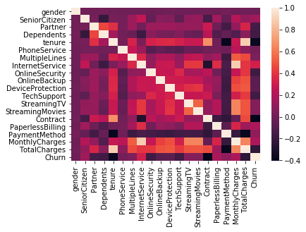

```python
import pandas as pd
import seaborn as sns
import matplotlib.pyplot as plt
corr = df.corr(method = 'spearman')

sns.heatmap(corr)

plt.show()
```

Tenemos multicolinealidad en algunas de las variables, así lo demuestra el plot, por lo tanto, debemos penalizar la regresión logística, en este caso la penalizaremos con "l1", esto hará que algunos coeficientes tiendan hacia 0, con esto se evitara el sobre ajuste.

```python
df_vars = df.columns.values.tolist()
Y = ['Churn']
X = [v for v in df_vars if v not in Y]
```

Seleccionamos la información para el modelo e inicialmente se utilizan todas las variables que son 19.

```python
from sklearn import datasets
from sklearn.feature_selection import RFE
from sklearn.linear_model import LogisticRegression


n = 19


lr = LogisticRegression(penalty='l1', solver='liblinear', class_weight='balanced', max_iter=10000)
rfe = RFE(lr, n_features_to_select=19)
rfe = rfe.fit(df[X], df[Y].values.ravel())
rfe
```

```
RFE(estimator=LogisticRegression(C=1.0, class_weight='balanced', dual=False,
                                 fit_intercept=True, intercept_scaling=1,
                                 l1_ratio=None, max_iter=10000,
                                 multi_class='auto', n_jobs=None, penalty='l1',
                                 random_state=None, solver='liblinear',
                                 tol=0.0001, verbose=0, warm_start=False),
    n_features_to_select=19, step=1, verbose=0)
```

Nos quedamos con las variables que aparezcan con "TRUE" y eliminamos las "FALSE"

```python
z=zip(df_vars,rfe.support_, rfe.ranking_)
list(z)
```

```
[('gender', True, 1),
 ('SeniorCitizen', True, 1),
 ('Partner', True, 1),
 ('Dependents', True, 1),
 ('tenure', True, 1),
 ('PhoneService', True, 1),
 ('MultipleLines', True, 1),
 ('InternetService', True, 1),
 ('OnlineSecurity', True, 1),
 ('OnlineBackup', True, 1),
 ('DeviceProtection', True, 1),
 ('TechSupport', True, 1),
 ('StreamingTV', True, 1),
 ('StreamingMovies', True, 1),
 ('Contract', True, 1),
 ('PaperlessBilling', True, 1),
 ('PaymentMethod', True, 1),
 ('MonthlyCharges', True, 1),
 ('TotalCharges', True, 1)]
```

Seleccionamos las variables con las que nos quedaremos, en este caso nos quedamos con todas las columnas, tampoco existe gran problema en un modelo robusto porque es un modelo penalizado.

```python
columnas = ['gender','SeniorCitizen','Partner','Dependents','tenure','PhoneService','MultipleLines','InternetService',
           'OnlineSecurity','OnlineBackup','DeviceProtection','TechSupport','StreamingTV','StreamingMovies','Contract',
           'PaperlessBilling','PaymentMethod','MonthlyCharges','TotalCharges']

X = df[columnas]
Y = df["Churn"]
```

Implementamos el modelo en Python con statsmodel.api

```python
import statsmodels.api as sm
logit_model = sm.Logit(Y, X)
result = logit_model.fit()
```

```
Optimization terminated successfully.
         Current function value: 0.416343
         Iterations 8
```

```python
result.summary2()
```

| Model: | Logit | Pseudo R-squared: | 0.281 |
| --- | --- | --- | --- |
| Dependent Variable: | Churn | AIC: | 5893.4460 |
| Date: | 2022-01-25 04:01 | BIC: | 6023.7523 |
| No. Observations: | 7032 | Log-Likelihood: | -2927.7 |
| Df Model: | 18 | LL-Null: | -4071.7 |
| Df Residuals: | 7013 | LLR p-value: | 0.0000 |
| Converged: | 1.0000 | Scale: | 1.0000 |
| No. Iterations: | 8.0000 |  |  |

|  | Coef. | Std.Err. | z | P>\|z\| | [0.025 | 0.975] |
| --- | --- | --- | --- | --- | --- | --- |
| gender | -0.0292 | 0.0645 | -0.4522 | 0.6512 | -0.1557 | 0.0973 |
| SeniorCitizen | 0.2360 | 0.0841 | 2.8059 | 0.0050 | 0.0712 | 0.4009 |
| Partner | 0.0144 | 0.0775 | 0.1856 | 0.8527 | -0.1374 | 0.1662 |
| Dependents | -0.1645 | 0.0894 | -1.8408 | 0.0657 | -0.3397 | 0.0107 |
| tenure | -1.4448 | 0.1506 | -9.5905 | 0.0000 | -1.7401 | -1.1495 |
| PhoneService | -1.2602 | 0.1017 | -12.3964 | 0.0000 | -1.4595 | -1.0610 |
| MultipleLines | 0.1117 | 0.0801 | 1.3935 | 0.1635 | -0.0454 | 0.2687 |
| InternetService | 0.1064 | 0.0735 | 1.4474 | 0.1478 | -0.0377 | 0.2505 |
| OnlineSecurity | -0.5675 | 0.0819 | -6.9274 | 0.0000 | -0.7281 | -0.4069 |
| OnlineBackup | -0.3174 | 0.0755 | -4.2051 | 0.0000 | -0.4654 | -0.1695 |
| DeviceProtection | -0.2061 | 0.0783 | -2.6338 | 0.0084 | -0.3595 | -0.0527 |
| TechSupport | -0.5519 | 0.0837 | -6.5942 | 0.0000 | -0.7159 | -0.3878 |
| StreamingTV | -0.0698 | 0.0826 | -0.8453 | 0.3980 | -0.2318 | 0.0921 |
| StreamingMovies | -0.0639 | 0.0817 | -0.7826 | 0.4339 | -0.2241 | 0.0962 |
| Contract | -0.7053 | 0.0770 | -9.1555 | 0.0000 | -0.8563 | -0.5543 |
| PaperlessBilling | 0.3638 | 0.0741 | 4.9104 | 0.0000 | 0.2186 | 0.5090 |
| PaymentMethod | 0.0455 | 0.0353 | 1.2876 | 0.1979 | -0.0237 | 0.1147 |
| MonthlyCharges | 0.8766 | 0.0828 | 10.5813 | 0.0000 | 0.7142 | 1.0389 |
| TotalCharges | 0.6884 | 0.1565 | 4.3978 | 0.0000 | 0.3816 | 0.9952 |

# Validamos el modelo

Para validar el modelo, nos quedamos con 0.3 de test y trabajaremos con un threshold de "0.5".

```python
import sklearn
from sklearn import linear_model
from sklearn.model_selection import train_test_split

#from sklearn import linear_model
#from sklearn.model_selection import train_test_split
X_train, X_test, Y_train, Y_test = train_test_split(X,Y, test_size = 0.3, random_state=12345)

lm = linear_model.LogisticRegression(penalty='l1', solver='liblinear')
lm.fit(X_train, Y_train)
```

```
LogisticRegression(C=1.0, class_weight=None, dual=False, fit_intercept=True,
                   intercept_scaling=1, l1_ratio=None, max_iter=100,
                   multi_class='auto', n_jobs=None, penalty='l1',
                   random_state=None, solver='liblinear', tol=0.0001, verbose=0,
                   warm_start=False)
```

```python
probs = lm.predict_proba(X_test)
prediction = lm.predict(X_test)
prob = probs[:,1]
prob_df = pd.DataFrame(prob)
threshold = 0.5
prob_df["prediction"] = np.where(prob_df[0]>threshold, 1, 0)
#prob_df.head()
pd.crosstab(prob_df.prediction, columns="count")
```

| col_0 prediction | count |
| --- | --- |
| 0 | 1644 |
| 1 | 466 |

Tenemos un 22% de clientes que son marcados como que abandonaran

```python
466/len(prob_df)*100
```

```
22.085308056872037
```

Si queremos saber cuanto acierta el modelo, en este caso obtenemos que este modelo acierta en un 80% de los casos en sí un cliente abandonara o no.

```python
from sklearn import metrics
metrics.accuracy_score(Y_test, prediction)
```

```
0.8061611374407583
```

Se realiza una validación cruzada para asegurar que nuestro modelo no tenga overfitting, y veremos que tan bien funciona el modelo o que tan bien discrimina en general.

```python
from sklearn.model_selection import cross_val_score
scores = cross_val_score(linear_model.LogisticRegression(penalty='l1', solver='liblinear'), X, Y, scoring="accuracy", cv=10)
scores
```

```
array([0.796875  , 0.80539773, 0.80227596, 0.83214794, 0.78236131,
       0.78662873, 0.80796586, 0.79943101, 0.80369844, 0.80227596])
```

Calculamos el promedio de la eficacia del modelo con 10 iteraciones obteniendo un 80%.

```python
scores.mean()
```

```
0.8019057933531618
```

Una vez que se ha validado el modelo, para asegurarnos que clasifica correctamente entre categorías, hacemos una curva ROC.

```python
X_train, X_test, Y_train, Y_test = train_test_split(X,Y,test_size=0.3, random_state=12345)
lm = linear_model.LogisticRegression(penalty='l1', solver='liblinear')
lm.fit(X_train, Y_train)
probs = lm.predict_proba(X_test)
prob=probs[:,1]
prob_df = pd.DataFrame(prob)
threshold = 0.50
prob_df["prediction"] = np.where(prob_df[0]>=threshold, 1, 0)
prob_df["actual"] = list(Y_test)
prob_df.head()
```

|  | 0 | prediction | actual |
| --- | --- | --- | --- |
| 0 | 0.135618 | 0 | 0 |
| 1 | 0.556369 | 1 | 1 |
| 2 | 0.044020 | 0 | 0 |
| 3 | 0.173034 | 0 | 0 |
| 4 | 0.118723 | 0 | 0 |

Calculamos la sensibilidad

```python
confusion_matrix = pd.crosstab(prob_df.prediction, prob_df.actual)
print(confusion_matrix)
TN=confusion_matrix[0][0]
TP=confusion_matrix[1][1]
FN=confusion_matrix[0][1]
FP=confusion_matrix[1][0]

sens = TP/(TP+FN)
sens
```

```
actual         0    1
prediction
0           1384  260
1            149  317
```

```
0.6802575107296137
```

Obtenemos que el 68% de los clientes que el modelo predijo que abandonaría realmente abandonaron.

Se calcula la especificidad:

```python
espc_1 = TN/(TN+FP)
espc_1
```

```
0.8418491484184915
```

Obtenemos una especificidad del 84%, esto significa que el % de clientes que se clasificaron como que "no" abandonarían y se clasificaron como tales.

Probamos la especificidad y la sensibilidad con varios "thresholds"

```python
thresholds = [0.04, 0.05, 0.07, 0.10, 0.12, 0.15, 0.18, 0.20, 0.25, 0.3, 0.4, 0.5]
sensitivities = [1]
especifities_1 = [1]

for t in thresholds:
    prob_df["prediction"] = np.where(prob_df[0]>=t, 1, 0)
    prob_df["actual"] = list(Y_test)
    prob_df.head()

    confusion_matrix = pd.crosstab(prob_df.prediction, prob_df.actual)
    TN=confusion_matrix[0][0]
    TP=confusion_matrix[1][1]
    FP=confusion_matrix[0][1]
    FN=confusion_matrix[1][0]

    sens = TP/(TP+FN)
    sensitivities.append(sens)
    espc_1 = 1-TN/(TN+FP)
    especifities_1.append(espc_1)

sensitivities.append(0)
especifities_1.append(0)

print(sensitivities)
```

```
[1, 0.9809358752166378, 0.9740034662045061, 0.9549393414211439, 0.9341421143847487, 0.9272097053726169, 0.9081455805892548, 0.8908145580589255, 0.8752166377816292, 0.8232235701906413, 0.7677642980935875, 0.6689774696707106, 0.5493934142114385, 0]
```

```python
print(especifities_1)
```

```
[1, 0.680365296803653, 0.6386170906718852, 0.5701239399869538, 0.5107632093933464, 0.4801043705153294, 0.4409654272667971, 0.3946510110893673, 0.3620352250489237, 0.28767123287671237, 0.24200913242009137, 0.16242661448140905, 0.0971950424005219, 0]
```

Comprobamos que tan bueno es el modelo y su capacidad para distinguir entre clases, para lo cual se utilizara la curva ROC y el Área bajo la curva.

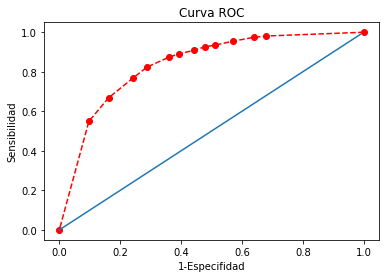

```python
import matplotlib.pyplot as plt
%matplotlib inline
plt.plot(especifities_1, sensitivities, marker="o", linestyle="--", color="r")
x=[i*0.01 for i in range(100)]
y=[i*0.01 for i in range(100)]
plt.plot(x,y)
plt.xlabel("1-Especifidad")
plt.ylabel("Sensibilidad")
plt.title("Curva ROC")
```

```python
import pandas as pd
import numpy as np
from sklearn.model_selection import train_test_split
from sklearn.linear_model import LogisticRegression
from sklearn import metrics
auc = metrics.roc_auc_score(Y_test, prob)
print(auc)
```

```
0.8455583178168111
```

El área bajo la curva nos grafica la precisión del modelo, mientras más alto sea el AUC mejor será el modelo, en este caso obtuvimos 0.84, dicho número cae en el rango de "bueno".

Finalmente, calculamos las razones de probabilidad y los intervalos de confianza para cada variable.

```python
params = result.params
conf = result.conf_int()
conf['Odds Ratio'] = params
conf.columns = ['5%', '95%', 'Odds Ratio']
print(np.exp(conf))
```

```
                        5%       95%  Odds Ratio
gender            0.855827  1.102212    0.971238
SeniorCitizen     1.073755  1.493217    1.266234
Partner           0.871585  1.180807    1.014482
Dependents        0.711951  1.010709    0.848278
tenure            0.175510  0.316787    0.235795
PhoneService      0.232362  0.346123    0.283594
MultipleLines     0.955624  1.308282    1.118135
InternetService   0.963017  1.284656    1.112271
OnlineSecurity    0.482840  0.665684    0.566938
OnlineBackup      0.627914  0.844113    0.728032
DeviceProtection  0.698021  0.948635    0.813737
TechSupport       0.488756  0.678524    0.575875
StreamingTV       0.793102  1.096486    0.932537
StreamingMovies   0.799241  1.100982    0.938056
Contract          0.424725  0.574458    0.493950
PaperlessBilling  1.244329  1.663661    1.438799
PaymentMethod     0.976531  1.121557    1.046535
MonthlyCharges    2.042549  2.826191    2.402631
TotalCharges      1.464627  2.705268    1.990530
```

Obtenemos la fuerza de asociación con para de una de las variables en relación a la variable dependiente, se podría destacar "MonthlyCharges" que aumenta la probabilidad de abandonar de manera considerable.